# Keystone-Exercice

AdrienM

2026-06-11

# Introduction

Here we are going to wrangling in messy data on the Ross River estuary fish surveys and produce final clean tables and figure. We have 4 separate files to wrangle in and use

# Housekeeping

# Packages

# Load files

# Main dataset

The catch data is split across 4 tabs in one excel file Load indivudally

# Inspect individual tabs

```
## # A tibble: 104 × 4
##    site       date                species       count
##    <chr>      <dttm>              <chr>         <dbl>
##  1 Lower_ross 2026-05-01 00:00:00 barramundi        6
##  2 Lower_ross 2026-05-01 00:00:00 MANGROVE JACK     3
##  3 Lower_ross 2026-05-01 00:00:00 bream             4
##  4 Lower_ross 2026-05-01 00:00:00 flathead          2
##  5 Lower_ross 2026-05-02 00:00:00 barramundi        1
##  6 Lower_ross 2026-05-02 00:00:00 MANGROVE JACK     1
##  7 Lower_ross 2026-05-02 00:00:00 bream             3
##  8 Lower_ross 2026-05-02 00:00:00 flathead          3
##  9 Lower_ross 2026-05-03 00:00:00 MANGROVE JACK     2
## 10 Lower_ross 2026-05-03 00:00:00 flathead          3
## # ℹ 94 more rows
```

```
## # A tibble: 106 × 4
##    site     date                species       count
##    <chr>    <dttm>              <chr>         <dbl>
##  1 Mid_Ross 2026-05-01 00:00:00 barramundi        4
##  2 Mid_Ross 2026-05-01 00:00:00 MANGROVE JACK     2
##  3 Mid_Ross 2026-05-01 00:00:00 bream             2
##  4 Mid_Ross 2026-05-01 00:00:00 flathead          3
##  5 Mid_Ross 2026-05-02 00:00:00 MANGROVE JACK     1
##  6 Mid_Ross 2026-05-02 00:00:00 bream             2
##  7 Mid_Ross 2026-05-02 00:00:00 flathead          3
##  8 Mid_Ross 2026-05-03 00:00:00 barramundi        3
##  9 Mid_Ross 2026-05-03 00:00:00 MANGROVE JACK     2
## 10 Mid_Ross 2026-05-03 00:00:00 bream             1
## # ℹ 96 more rows
```

```
## # A tibble: 107 × 4
##    site       date                species       count
##    <chr>      <dttm>              <chr>         <dbl>
##  1 ROSS MOUTH 2026-05-01 00:00:00 barramundi        3
##  2 ROSS MOUTH 2026-05-01 00:00:00 MANGROVE JACK     2
##  3 ROSS MOUTH 2026-05-01 00:00:00 flathead          9
##  4 ROSS MOUTH 2026-05-02 00:00:00 MANGROVE JACK     1
##  5 ROSS MOUTH 2026-05-02 00:00:00 bream             3
##  6 ROSS MOUTH 2026-05-02 00:00:00 flathead          4
##  7 ROSS MOUTH 2026-05-03 00:00:00 barramundi        1
##  8 ROSS MOUTH 2026-05-03 00:00:00 MANGROVE JACK     1
##  9 ROSS MOUTH 2026-05-03 00:00:00 bream             2
## 10 ROSS MOUTH 2026-05-03 00:00:00 flathead          7
## # ℹ 97 more rows
```

```
## # A tibble: 110 × 4
##    site       date                species       count
##    <chr>      <dttm>              <chr>         <dbl>
##  1 Upper Ross 2026-05-01 00:00:00 barramundi        5
##  2 Upper Ross 2026-05-01 00:00:00 bream             2
##  3 Upper Ross 2026-05-01 00:00:00 flathead          6
##  4 Upper Ross 2026-05-02 00:00:00 barramundi        8
##  5 Upper Ross 2026-05-02 00:00:00 MANGROVE JACK     1
##  6 Upper Ross 2026-05-02 00:00:00 bream             2
##  7 Upper Ross 2026-05-02 00:00:00 flathead          4
##  8 Upper Ross 2026-05-03 00:00:00 barramundi        4
##  9 Upper Ross 2026-05-03 00:00:00 bream             2
## 10 Upper Ross 2026-05-04 00:00:00 barramundi        5
## # ℹ 100 more rows
```

# Bind rows together

# Examine data

```
## # A tibble: 427 × 4
##    site       date                species       count
##    <chr>      <dttm>              <chr>         <dbl>
##  1 Lower_ross 2026-05-01 00:00:00 barramundi        6
##  2 Lower_ross 2026-05-01 00:00:00 MANGROVE JACK     3
##  3 Lower_ross 2026-05-01 00:00:00 bream             4
##  4 Lower_ross 2026-05-01 00:00:00 flathead          2
##  5 Lower_ross 2026-05-02 00:00:00 barramundi        1
##  6 Lower_ross 2026-05-02 00:00:00 MANGROVE JACK     1
##  7 Lower_ross 2026-05-02 00:00:00 bream             3
##  8 Lower_ross 2026-05-02 00:00:00 flathead          3
##  9 Lower_ross 2026-05-03 00:00:00 MANGROVE JACK     2
## 10 Lower_ross 2026-05-03 00:00:00 flathead          3
## # ℹ 417 more rows
```

```
## # A tibble: 6 × 4
##   site       date                species       count
##   <chr>      <dttm>              <chr>         <dbl>
## 1 Lower_ross 2026-05-01 00:00:00 barramundi        6
## 2 Lower_ross 2026-05-01 00:00:00 MANGROVE JACK     3
## 3 Lower_ross 2026-05-01 00:00:00 bream             4
## 4 Lower_ross 2026-05-01 00:00:00 flathead          2
## 5 Lower_ross 2026-05-02 00:00:00 barramundi        1
## 6 Lower_ross 2026-05-02 00:00:00 MANGROVE JACK     1
```

```
## Rows: 427
## Columns: 4
## $ site    <chr> "Lower_ross", "Lower_ross", "Lower_ross", "Lower_ross", "Lower…
## $ date    <dttm> 2026-05-01, 2026-05-01, 2026-05-01, 2026-05-01, 2026-05-02, 2…
## $ species <chr> "barramundi", "MANGROVE JACK", "bream", "flathead", "barramund…
## $ count   <dbl> 6, 3, 4, 2, 1, 1, 3, 3, 2, 3, 1, 8, 4, 1, 1, 2, 1, 2, 4, 2, 2,…
```

```
## tibble [427 × 4] (S3: tbl_df/tbl/data.frame)
##  $ site   : chr [1:427] "Lower_ross" "Lower_ross" "Lower_ross" "Lower_ross" ...
##  $ date   : POSIXct[1:427], format: "2026-05-01" "2026-05-01" ...
##  $ species: chr [1:427] "barramundi" "MANGROVE JACK" "bream" "flathead" ...
##  $ count  : num [1:427] 6 3 4 2 1 1 3 3 2 3 ...
```

Can’t tell from these outputs how many levels of site and species we have. Two options: let’s check those explicitly by using distinct() or can convert to factors Let’s look at the distinct values first, as we might need to clean before converting to factor vars.

```
## # A tibble: 4 × 1
##   site
##   <chr>
## 1 Lower_ross
## 2 Mid_Ross
## 3 ROSS MOUTH
## 4 Upper Ross
```

```
## # A tibble: 4 × 1
##   species
##   <chr>
## 1 barramundi
## 2 MANGROVE JACK
## 3 bream
## 4 flathead
```

OK, so we have four species in there as well as four sites which look to be located at different points on the Ross River. Need to: - Fix site names and place in reasonable order. - Can decide this now or we can load the metadata and ensure consistency - Fix species names - to do this we’ll need to make consistent and then use the taxonomic dictionary to translate to scientific names.

# Load metadata

# Inspect

```
## # A tibble: 4 × 4
##   site_name    lat   lon zone
##   <chr>      <dbl> <dbl> <chr>
## 1 Upper_Ross -19.3  147. Upstream
## 2 mid_ross   -19.3  147. Middle
## 3 LOWER ROSS -19.3  147. Downstream
## 4 ross_mouth -19.2  147. Marine
```

```
## Rows: 4
## Columns: 4
## $ site_name <chr> "Upper_Ross", "mid_ross", "LOWER ROSS", "ross_mouth"
## $ lat       <dbl> -19.31, -19.28, -19.26, -19.25
## $ lon       <dbl> 146.74, 146.78, 146.81, 146.83
## $ zone      <chr> "Upstream", "Middle", "Downstream", "Marine"
```

Site names are all over the place in the metadata too - will need to standardise.

# Recheck

```
## tibble [427 × 4] (S3: tbl_df/tbl/data.frame)
##  $ site   : Factor w/ 4 levels "lower_ross","mid_ross",..: 1 1 1 1 1 1 1 1 1 1 ...
##  $ date   : POSIXct[1:427], format: "2026-05-01" "2026-05-01" ...
##  $ species: Factor w/ 4 levels "barramundi","MANGROVE JACK",..: 1 2 3 4 1 2 3 4 2 4 ...
##  $ count  : num [1:427] 6 3 4 2 1 1 3 3 2 3 ...
```

```
## Rows: 4
## Columns: 4
## $ site_name <fct> upper_ross, mid_ross, lower_ross, ross_mouth
## $ lat       <dbl> -19.31, -19.28, -19.26, -19.25
## $ lon       <dbl> 146.74, 146.78, 146.81, 146.83
## $ zone      <fct> Upstream, Middle, Downstream, Marine
```

# Load Taxonomic Dictionary

```
## # A tibble: 4 × 2
##   common_name   scientific_name
##   <chr>         <chr>
## 1 barramundi    Lates calcarifer
## 2 mangrove_jack Lutjanus argentimaculatus
## 3 bream         Acanthopagrus spp.
## 4 flathead      Platycephalus spp.
```

# Load sensor data

# Check sensor data

```
##         site        timestamp temperature  salinity turbidity
## 1 upper_ross 01/05/2026 00:00    23.71379  4.054812  6.489046
## 2   mid_ross 01/05/2026 00:00    24.13302 15.742962 49.216967
## 3 lower_ross 01/05/2026 00:00    24.23558 28.934938 48.135752
## 4 ross_mouth 01/05/2026 00:00    24.64147 33.891350 49.811493
## 5 upper_ross 01/05/2026 00:15    26.06955  3.962750 25.184739
## 6   mid_ross 01/05/2026 00:15    24.62576 12.053501 34.816596
```

```
## 'data.frame':    11520 obs. of  5 variables:
##  $ site       : chr  "upper_ross" "mid_ross" "lower_ross" "ross_mouth" ...
##  $ timestamp  : chr  "01/05/2026 00:00" "01/05/2026 00:00" "01/05/2026 00:00" "01/05/2026 00:00" ...
##  $ temperature: num  23.7 24.1 24.2 24.6 26.1 ...
##  $ salinity   : num  4.05 15.74 28.93 33.89 3.96 ...
##  $ turbidity  : num  6.49 49.22 48.14 49.81 25.18 ...
```

```
## Rows: 11,520
## Columns: 5
## $ site        <chr> "upper_ross", "mid_ross", "lower_ross", "ross_mouth", "upp…
## $ timestamp   <chr> "01/05/2026 00:00", "01/05/2026 00:00", "01/05/2026 00:00"…
## $ temperature <dbl> 23.71379, 24.13302, 24.23558, 24.64147, 26.06955, 24.62576…
## $ salinity    <dbl> 4.054812, 15.742962, 28.934938, 33.891350, 3.962750, 12.05…
## $ turbidity   <dbl> 6.489046, 49.216967, 48.135752, 49.811493, 25.184739, 34.8…
```

```
##      site            timestamp          temperature       salinity
##  Length:11520       Length:11520       Min.   :18.14   Min.   :-2.224
##  Class :character   Class :character   1st Qu.:23.00   1st Qu.: 8.268
##  Mode  :character   Mode  :character   Median :24.01   Median :22.255
##                                        Mean   :24.00   Mean   :20.462
##                                        3rd Qu.:24.98   3rd Qu.:32.500
##                                        Max.   :29.61   Max.   :37.773
##    turbidity
##  Min.   :-999.00
##  1st Qu.:  11.59
##  Median :  24.36
##  Mean   : -24.87
##  3rd Qu.:  37.04
##  Max.   :  50.00
```

# Clean up sensor data

# Summarise 15-minute sonde data into daily means

#### Notes:

- Environmental variables needed cleaning:
- Turbidity data has a failed value (-999)
- Salinity had some negative values which are not possible and should be converted to NA
- Site ok

# Standardise variable in the catch log to match dictionaries

## Check common names in catch log match those in the taxonomic dictionary

```
## # A tibble: 4 × 1
##   species
##   <chr>
## 1 barramundi
## 2 mangrove_jack
## 3 bream
## 4 flathead
```

```
## # A tibble: 4 × 1
##   common_name
##   <chr>
## 1 barramundi
## 2 mangrove_jack
## 3 bream
## 4 flathead
```

# Taxonomic Translation (Common to Scientific)

# Need to:

1. Join with metadata and sensor data
2. Implicit zero observations 4 x spp 4 x sites 30 surveys

4*4*30

# join catch data with metadata and sensor data

```
## # A tibble: 480 × 12
##    site       date                zone    mean_temp mean_salinity mean_turbidity
##    <chr>      <dttm>              <fct>       <dbl>         <dbl>          <dbl>
##  1 lower_ross 2026-05-01 00:00:00 Downst…      23.8          28.4           27.9
##  2 lower_ross 2026-05-01 00:00:00 Downst…      23.8          28.4           27.9
##  3 lower_ross 2026-05-01 00:00:00 Downst…      23.8          28.4           27.9
##  4 lower_ross 2026-05-01 00:00:00 Downst…      23.8          28.4           27.9
##  5 lower_ross 2026-05-02 00:00:00 Downst…      24.0          27.7           24.1
##  6 lower_ross 2026-05-02 00:00:00 Downst…      24.0          27.7           24.1
##  7 lower_ross 2026-05-02 00:00:00 Downst…      24.0          27.7           24.1
##  8 lower_ross 2026-05-02 00:00:00 Downst…      24.0          27.7           24.1
##  9 lower_ross 2026-05-03 00:00:00 Downst…      24.2          28.1           20.6
## 10 lower_ross 2026-05-03 00:00:00 Downst…      24.2          28.1           20.6
## # ℹ 470 more rows
## # ℹ 6 more variables: scientific_name <chr>, species <chr>, count <dbl>,
## #   common_name <chr>, lat <dbl>, lon <dbl>
```

### Produce summary table of salinity by species and zone

```
## # A tibble: 16 × 4
##    scientific_name           zone       sem_salinity median_salinity
##    <chr>                     <fct>             <dbl>           <dbl>
##  1 Acanthopagrus spp.        Upstream          0.294            4.98
##  2 Acanthopagrus spp.        Middle            0.279           15.0
##  3 Acanthopagrus spp.        Downstream        0.255           27.9
##  4 Acanthopagrus spp.        Marine            0.347           34.0
##  5 Lates calcarifer          Upstream          0.309            4.99
##  6 Lates calcarifer          Middle            0.231           15.0
##  7 Lates calcarifer          Downstream        0.262           27.9
##  8 Lates calcarifer          Marine            0.254           34.0
##  9 Lutjanus argentimaculatus Upstream          0.195            5.00
## 10 Lutjanus argentimaculatus Middle            0.171           15.0
## 11 Lutjanus argentimaculatus Downstream        0.304           27.9
## 12 Lutjanus argentimaculatus Marine            0.193           34.0
## 13 Platycephalus spp.        Upstream          0.328            5.02
## 14 Platycephalus spp.        Middle            0.251           14.9
## 15 Platycephalus spp.        Downstream        0.165           27.9
## 16 Platycephalus spp.        Marine            0.237           34.0
```

#Make plot and error plot

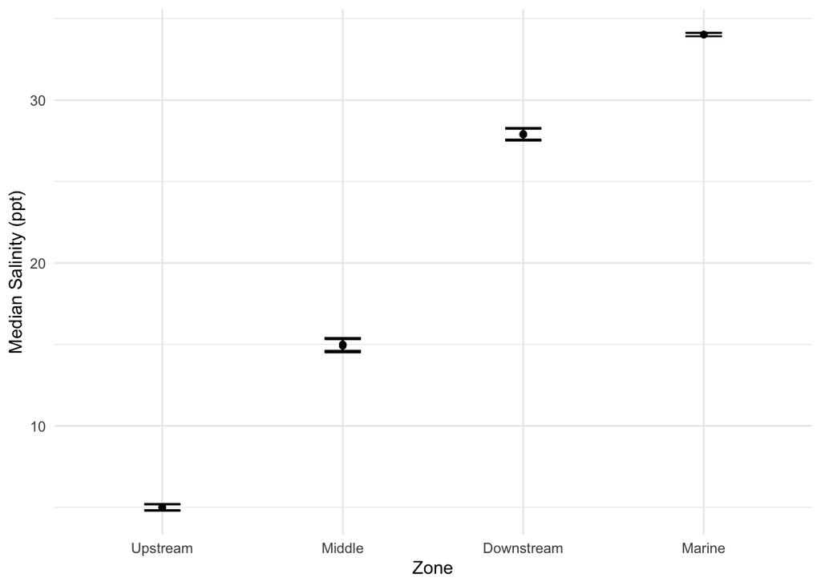

#Now Calculate

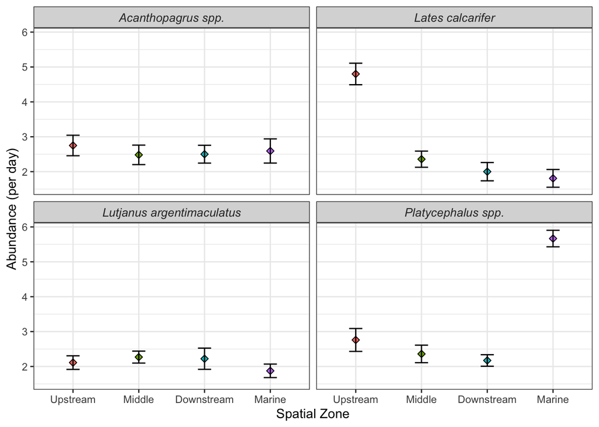